# Exploratorium

Anwesha Guha

2025-05-06

```r
load(here("data", "combined_clean.RData"))
```

## Weight exploration

The weighted tutorial notes to calibrate weights to standardize mean? I am just curious about what these weights look like, so let’s see weight 2. Strange that there are so many NAs.

```r
summary(full$rep_weight_2) #1,199
```

```
##     Min.  1st Qu.   Median     Mean  3rd Qu.     Max.     NA's
##     28.8   1287.1   3524.8   7824.3   8023.1 223844.8     1199
```

```r
length(unique(full$id)) #63,181 weights -- #43,932 IDs
```

```
## [1] 43932
```

Note for weights (from video): - `survey` package in R can handle weights - use BRR variance estimation (another option is linearization/Taylor Series) - cross-sectional weights are specific to wave; single-wave is slightly different. We have the cross-sectional weights since we are looking at overall characteristics of the Wave 4 vs Wave 7 samples. If we were interested in individual-level tracking, we’d use the all-waves weights, but that’s not relevant to our RQs.

## Omitting weights

### Data exploration

Create variable factors and strata.

```r
full %>%
 dplyr::select(-contains("weight")) %>%
 mutate(across(2:7, as.factor)) %>%
 mutate(race_ethnicity = as.factor(paste0(race, ", ", ethnicity)),
        strata_label = paste(region, race_ethnicity, sexuality, sex, age, sep = "_")) %>%
 head()
```

```
##           id    region    ethnicity  race    sexuality    sex   age eprod_edsd
## 1 P000000005 Northeast     Hispanic Black     Straight Female   45+          0
## 2 P000000012 Northeast Not Hispanic White     Straight   Male 18-24          0
## 3 P000000030   Midwest Not Hispanic White Not straight Female 25-44          0
## 4 P000000074      West Not Hispanic White     Straight Female 18-24          0
## 5 P000000081      West     Hispanic White Not straight   Male 18-24          0
## 6 P000000090     South Not Hispanic Black     Straight Female 25-44          0
##   eprod_established var_strat var_psu wave period northeast midwest south west
## 1                 0        11       2    4      0         1       0     0    0
## 2                 0        69       2    4      0         1       0     0    0
## 3                 0        53       2    4      0         0       1     0    0
## 4                 0        99       1    4      0         0       0     0    1
## 5                 0        39       2    4      0         0       0     0    1
## 6                 0        17       2    4      0         0       0     1    0
##   hispanic white black other straight gay female male age_18_24 age_25_44
```

[output cut: 20 more lines]

Descriptive summary by strata

```r
full %>%
  dplyr::select(-contains("weight")) %>%
 mutate(across(2:7, as.factor)) %>%
 mutate(race_ethnicity = as.factor(paste0(race, ", ", ethnicity)),
        strata_label = paste(region, race_ethnicity, sexuality, sex, age, sep = "_")) %>%
 group_by(strata_label) %>%
 summarise(tot = sum(eprod_edsd)) %>%
 arrange(tot)
```

```
## # A tibble: 432 × 2
##    strata_label                                      tot
##    <chr>                                           <dbl>
##  1 Midwest_Black, Hispanic_NA_Female_25-44             0
##  2 Midwest_Black, Hispanic_NA_Female_45+               0
##  3 Midwest_Black, Hispanic_Not straight_Male_45+       0
##  4 Midwest_Black, Hispanic_Straight_NA_NA              0
##  5 Midwest_Black, Not Hispanic_NA_Female_18-24         0
##  6 Midwest_Black, Not Hispanic_NA_Male_18-24           0
##  7 Midwest_Black, Not Hispanic_Straight_NA_45+         0
##  8 Midwest_Other, Hispanic_NA_Male_45+                 0
##  9 Midwest_Other, Hispanic_Not straight_Female_45+     0
## 10 Midwest_Other, Hispanic_Not straight_Male_45+       0
## # ℹ 422 more rows
```

Remove NA values? What is the best method we want to use?

I’m doing listwise just to continue on with the exploration.

```r
full %>%
 dplyr::select(-contains("weight")) %>%
 mutate(across(2:7, as.factor)) %>%
 mutate(race_ethnicity = as.factor(paste0(race, ", ", ethnicity)),
        strata_label = paste(region, race_ethnicity, sexuality, sex, age, sep = "_")) %>%
 filter(wave == 4) %>%
 dplyr::select(1:8, strata_label) %>% #33,822
 drop_na() %>% #33,389
 group_by(strata_label) %>%
 summarise(tot = sum(eprod_edsd))
```

```
## # A tibble: 278 × 2
##    strata_label                                            tot
##    <chr>                                                 <dbl>
##  1 Midwest_Black, Hispanic_Not straight_Female_18-24         0
##  2 Midwest_Black, Hispanic_Not straight_Male_45+             0
##  3 Midwest_Black, Hispanic_Straight_Female_18-24             0
##  4 Midwest_Black, Hispanic_Straight_Female_25-44             0
##  5 Midwest_Black, Hispanic_Straight_Female_45+               2
##  6 Midwest_Black, Hispanic_Straight_Male_18-24               0
##  7 Midwest_Black, Hispanic_Straight_Male_25-44               0
##  8 Midwest_Black, Hispanic_Straight_Male_45+                 0
##  9 Midwest_Black, Not Hispanic_Not straight_Female_18-24     5
## 10 Midwest_Black, Not Hispanic_Not straight_Female_25-44     2
## # ℹ 268 more rows
```

We have 278 strata if we keep all of these. Not use sexual orientation b/c not imputed. Omit that from analysis. I’ll take out this variable and modify the race/ethnicity coding.

### Data prep

```r
dat <- full %>%
 dplyr::select(-contains("weight")) %>%
 mutate(across(region:age, as.factor)) %>%
 mutate(race_ethnicity = as.factor(case_when(race == "Black" & ethnicity == "Not Hispanic" ~ "Black",
                                   race == "White" & ethnicity == "Not Hispanic" ~ "White",
                                   ethnicity == "Hispanic" ~ "Hispanic",
                                   TRUE ~ "Other"))) %>%
 dplyr::select(id, #ID
        wave, #wave
        region, race_ethnicity, sex, age, #strata
        eprod_edsd #outcome
        )
#64,623 observations
```

```r
dat <- dat %>%
 drop_na() #64,539

#84 observations with any missing values

dat <- dat %>%
 mutate(strata_label = as.factor(paste(region, race_ethnicity, sex, age, sep = "_")))
```

Let’s see how many individuals we have in each strata (and if any are empty).

```r
dat %>%
 group_by(strata_label) %>%
 summarize(tot = sum(eprod_edsd)) %>%
 arrange(tot)
```

```
## # A tibble: 96 × 2
##    strata_label                    tot
##    <fct>                         <dbl>
##  1 Northeast_Other_Male_45+          1
##  2 West_Other_Male_45+               4
##  3 Midwest_Hispanic_Male_45+         5
##  4 Northeast_Black_Male_45+          5
##  5 West_Black_Male_45+               5
##  6 Midwest_Other_Female_45+          6
##  7 Midwest_Other_Male_45+            6
##  8 Northeast_Black_Female_45+        6
##  9 Northeast_Hispanic_Female_45+     6
## 10 Northeast_Other_Female_45+        7
## # ℹ 86 more rows
```

We might consider doing some combining. At the very least, let’s combine “Northeast_Other_Male_45+” and “West_Other_Male_45+” so the minimum n of any given strata is 5.

```r
dat <- dat %>%
 mutate(strata_label = case_when(
    strata_label %in% c("Northeast_Other_Male_45+", "West_Other_Male_45+") ~ "NortheastWest_Other_Male_45+",
    TRUE ~ strata_label
  ))
```

Check if it worked.

```r
dat %>%
 group_by(strata_label) %>%
 summarize(tot = sum(eprod_edsd)) %>%
 arrange(tot)
```

```
## # A tibble: 95 × 2
##    strata_label                    tot
##    <chr>                         <dbl>
##  1 Midwest_Hispanic_Male_45+         5
##  2 NortheastWest_Other_Male_45+      5
##  3 Northeast_Black_Male_45+          5
##  4 West_Black_Male_45+               5
##  5 Midwest_Other_Female_45+          6
##  6 Midwest_Other_Male_45+            6
##  7 Northeast_Black_Female_45+        6
##  8 Northeast_Hispanic_Female_45+     6
##  9 Northeast_Other_Female_45+        7
## 10 Northeast_Hispanic_Male_45+       8
## # ℹ 85 more rows
```

Question: this works for the strata, but how do we do that for the additive model?

### Running the models

From Evans et al. (2024): linear models are fit using restricted maximum likelihood estimation (RMLE) using the function lmer, and logistic models are fitted using a Laplace Approximation of maximum likelihood estimation using the funtion glmer.

Our outcome is everyday/someday E-product usage (`eprod_edsd`).

#### Null model

```r
library(lme4)
mod1 <- glmer(eprod_edsd ~ (1 | strata_label),
               data = dat,
               family = binomial(link = "logit"))

summary(mod1)
```

```
## Generalized linear mixed model fit by maximum likelihood (Laplace
##   Approximation) [glmerMod]
##  Family: binomial  ( logit )
## Formula: eprod_edsd ~ (1 | strata_label)
##    Data: dat
##
##      AIC      BIC   logLik deviance df.resid
##  42754.2  42772.4 -21375.1  42750.2    64537
##
## Scaled residuals:
##     Min      1Q  Median      3Q     Max
## -0.5131 -0.3911 -0.3189 -0.2255  5.3415
##
## Random effects:
##  Groups       Name        Variance Std.Dev.
##  strata_label (Intercept) 0.3191   0.5649
## Number of obs: 64539, groups:  strata_label, 95
##
## Fixed effects:
##             Estimate Std. Error z value Pr(>|z|)
## (Intercept) -2.28587    0.06176  -37.01   <2e-16 ***
## ---
## Signif. codes:  0 '***' 0.001 '**' 0.01 '*' 0.05 '.' 0.1 ' ' 1
```

```r
# Predict the fitted linear predictor (on the probability scale)
dat$mod1xbu <- predict(mod1, type = "response")

# Predict the linear predictor for the fixed portion of the model only
# (only the intercept, so this is just the weighted grand mean probability)
dat$mod1xb <- predict(mod1, type="response", re.form=NA)
```

#### Additive model

```r
library(merTools)
mod2 <- glmer(eprod_edsd ~ region + race_ethnicity + sex + age + (1 | strata_label),
                data = dat,
                family = binomial(link = "logit"))

summary(mod2)
```

```
## Generalized linear mixed model fit by maximum likelihood (Laplace
##   Approximation) [glmerMod]
##  Family: binomial  ( logit )
## Formula: eprod_edsd ~ region + race_ethnicity + sex + age + (1 | strata_label)
##    Data: dat
##
##      AIC      BIC   logLik deviance df.resid
##  42621.0  42720.9 -21299.5  42599.0    64528
##
## Scaled residuals:
##     Min      1Q  Median      3Q     Max
## -0.5023 -0.3930 -0.3221 -0.2319  5.8070
##
## Random effects:
##  Groups       Name        Variance Std.Dev.
##  strata_label (Intercept) 0.03421  0.185
## Number of obs: 64539, groups:  strata_label, 95
##
## Fixed effects:
##                        Estimate Std. Error z value Pr(>|z|)
## (Intercept)            -2.10061    0.08493 -24.734  < 2e-16 ***
## regionNortheast        -0.25282    0.07953  -3.179 0.001479 **
## regionSouth            -0.03897    0.07014  -0.556 0.578454
## regionWest             -0.07721    0.07418  -1.041 0.297898
## race_ethnicityHispanic  0.10928    0.08016   1.363 0.172774
## race_ethnicityOther     0.41531    0.08517   4.876 1.08e-06 ***
## race_ethnicityWhite     0.48971    0.07371   6.644 3.06e-11 ***
## sexMale                 0.13757    0.05179   2.657 0.007895 **
## age25-44               -0.21485    0.05922  -3.628 0.000286 ***
## age45+                 -1.16898    0.06828 -17.121  < 2e-16 ***
## ---
## Signif. codes:  0 '***' 0.001 '**' 0.01 '*' 0.05 '.' 0.1 ' ' 1
##
## Correlation of Fixed Effects:
##             (Intr) rgnNrt rgnSth rgnWst rc_thH rc_thO rc_thW sexMal a25-44
## reginNrthst -0.385
## regionSouth -0.478  0.495
## regionWest  -0.373  0.474  0.532
## rc_thnctyHs -0.504 -0.054 -0.007 -0.126
## rc_thnctyOt -0.496 -0.012  0.020 -0.086  0.533
## rc_thnctyWh -0.559 -0.044  0.056 -0.063  0.607  0.576
## sexMale     -0.309 -0.002 -0.002 -0.003 -0.003 -0.004  0.000
## age25-44    -0.343 -0.001 -0.013 -0.013  0.025  0.018  0.003  0.004
## age45+      -0.304  0.021 -0.025 -0.005  0.053  0.051 -0.054  0.023  0.423
```

```r
# Predict the fitted linear predictor (on the probability scale)
dat$mod2m <- predict(mod2, type = "response")


# predict the fitted linear predictor, and confidence intervals, on the logit
# scale
m2m <- predictInterval(mod2, level=0.95, include.resid.var=FALSE)
# create a new id variable for this newly created dataframe
m2m <- mutate(m2m, id=row_number())

# on the logit scale, predict the linear predictor for the fixed portion of the
# model only
dat$m2mF <- predict(mod2, re.form=NA)

# predict the fitted linear predictor, and confidence intervals, on the
# probability scale
m2m_prob <- predictInterval(mod2, level=0.95, include.resid.var=FALSE,
                             type="probability")
# note that, unlike the stata code, this code combines the uncertainty from the
# fixed and random parts. This saves a step later compared to the Stata code.

# create a new id variable for this newly created dataframe
m2m_prob <- mutate(m2m_prob, id=row_number())

# predict the fitted linear predictor, on the probability scale, for the fixed
# portion of the model only
dat$m2xb <- predict(mod2, re.form=NA, type="response")

#predict the stratum random effects and associated standard errors
m2u <- REsim(mod2)
```

```r
vc1a <-as.data.frame(VarCorr(mod1))
vc1b <-as.data.frame(VarCorr(mod2))

PCV1 <- ((vc1a[1,4] - vc1b[1,4]) / vc1a[1,4])*100
PCV1 #89.28
```

```
## [1] 89.27798
```

### Visualizations

#### Histograms

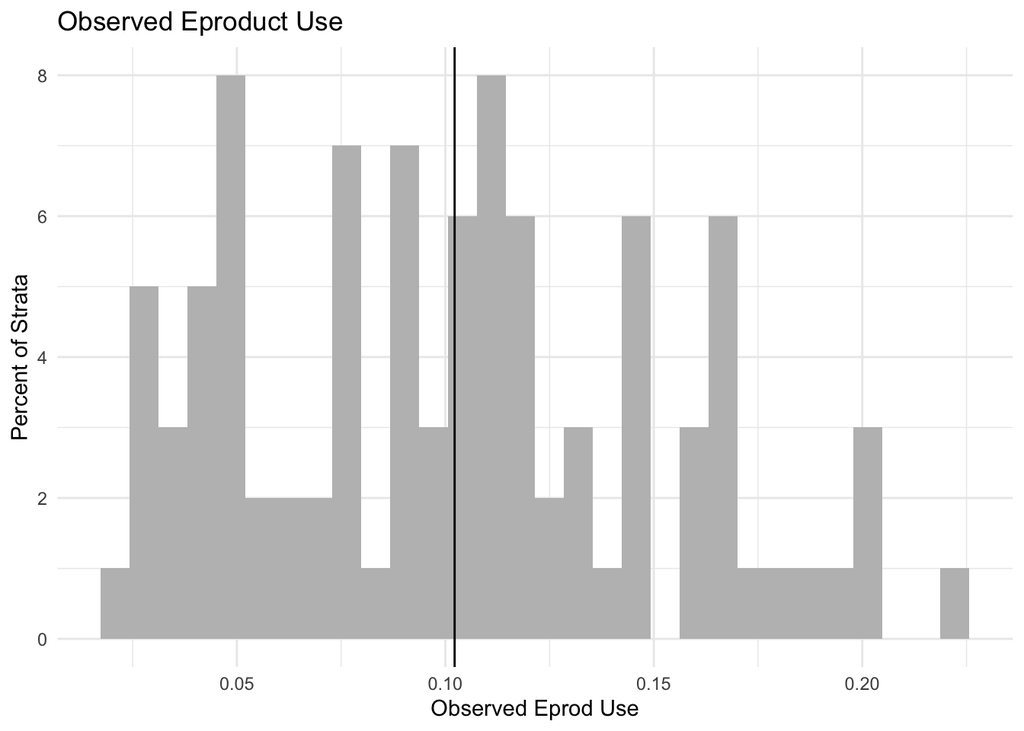

```r
# Histogram of the observed stratum means (and mean of means)
dat %>%
 group_by(strata_label) %>%
 summarise(avg = mean(eprod_edsd)) %>%
 ggplot(., aes(avg)) +
 geom_histogram(fill = "gray") +
  labs(title = "Observed Eproduct Use",
       x = "Observed Eprod Use",
       y = "Percent of Strata") +
 geom_vline(aes(xintercept = mean(avg))) +
 theme_minimal()
```

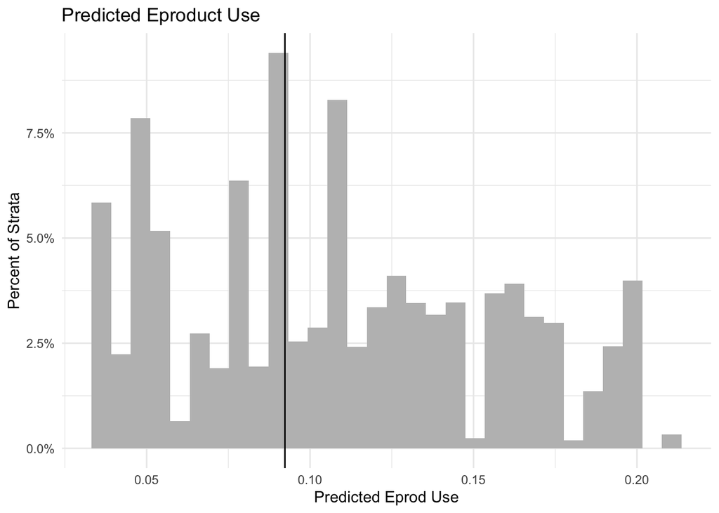

```r
# Histogram of the predicted stratum means
ggplot(dat, aes(x=mod1xbu)) +
  geom_histogram(aes(y = after_stat(count / sum(count))), fill = "gray") +
  scale_y_continuous(labels=scales::percent) +
  labs(title = "Predicted Eproduct Use",
       x = "Predicted Eprod Use",
       y = "Percent of Strata") +
  geom_vline(aes(xintercept=0.0923))+ #this is the precision weighted grand mean
  theme_minimal()
```

#### Ranks

Okay, stopping here.

Notes for later: - Elaborate, why not chisq or single-level? - Create colorful caterpillar plots